# ex

```python
import polars as pl
import numpy as np
from scipy import stats as st
import matplotlib.pyplot as plt
import seaborn as sns
import networkx as nx
from scipy.spatial.distance import pdist, squareform
from sklearn.metrics import silhouette_score
```

1. Первичная обработка данных

```python
full_df = pl.read_excel("./24_MAG_Exam_Practice_34.xls", has_header=False)
full_df = full_df.rename(
    dict(
        zip(
            [f"column_{i}" for i in range(1, 10)],
            [
                "age",
                "num_dependants",
                "income",
                "years_in_region",
                "car_value",
                "credit_value",
                "drop_0",
                "drop_1",
                "is_a_good_client"
            ],
        )
    )
)
full_df = full_df.drop("drop_0", "drop_1")
full_df
```

shape: (70, 7)

| age i64 | num_dependants i64 | income i64 | years_in_region i64 | car_value i64 | credit_value i64 | is_a_good_client i64 |
| --- | --- | --- | --- | --- | --- | --- |
| 38 | 1 | 7500 | 9 | 7000 | 71000 | 1 |
| 38 | 2 | 31900 | 8 | 32000 | 319000 | 0 |
| 29 | 1 | 25000 | 3 | 23000 | 237000 | 0 |
| 54 | 4 | 23100 | 18 | 26000 | 249000 | 1 |
| 33 | 2 | 31800 | 5 | 31000 | 311000 | 0 |
| … | … | … | … | … | … | … |
| 30 | 1 | 19400 | 4 | 17000 | 182000 | 0 |
| 41 | 2 | 30500 | 10 | 31000 | 308000 | 0 |
| 44 | 3 | 21900 | 12 | 23000 | 224000 | 0 |
| 50 | 3 | 13800 | 16 | 16000 | 149000 | 1 |
| 28 | 1 | 22300 | 3 | 20000 | 208000 | 0 |

```python
df = full_df.drop("is_a_good_client")
```

Рассмотрим только признаки заемщиков:

```python
df
```

shape: (70, 6)

| age i64 | num_dependants i64 | income i64 | years_in_region i64 | car_value i64 | credit_value i64 |
| --- | --- | --- | --- | --- | --- |
| 38 | 1 | 7500 | 9 | 7000 | 71000 |
| 38 | 2 | 31900 | 8 | 32000 | 319000 |
| 29 | 1 | 25000 | 3 | 23000 | 237000 |
| 54 | 4 | 23100 | 18 | 26000 | 249000 |
| 33 | 2 | 31800 | 5 | 31000 | 311000 |
| … | … | … | … | … | … |
| 30 | 1 | 19400 | 4 | 17000 | 182000 |
| 41 | 2 | 30500 | 10 | 31000 | 308000 |
| 44 | 3 | 21900 | 12 | 23000 | 224000 |
| 50 | 3 | 13800 | 16 | 16000 | 149000 |
| 28 | 1 | 22300 | 3 | 20000 | 208000 |

```python
df.describe()
```

shape: (9, 7)

| statistic str | age f64 | num_dependants f64 | income f64 | years_in_region f64 | car_value f64 | credit_value f64 |
| --- | --- | --- | --- | --- | --- | --- |
| "count" | 70.0 | 70.0 | 70.0 | 70.0 | 70.0 | 70.0 |
| "null_count" | 0.0 | 0.0 | 0.0 | 0.0 | 0.0 | 0.0 |
| "mean" | 39.985714 | 2.071429 | 20000.0 | 9.957143 | 20014.285714 | 200014.285714 |
| "std" | 8.074818 | 1.026058 | 9999.391286 | 5.017175 | 9927.991255 | 100000.361283 |
| "min" | 20.0 | -1.0 | 2600.0 | -2.0 | 2000.0 | 19000.0 |
| "25%" | 34.0 | 1.0 | 11300.0 | 6.0 | 12000.0 | 119000.0 |
| "50%" | 39.0 | 2.0 | 20700.0 | 9.0 | 20000.0 | 200000.0 |
| "75%" | 47.0 | 3.0 | 27100.0 | 14.0 | 27000.0 | 266000.0 |
| "max" | 60.0 | 5.0 | 40300.0 | 22.0 | 43000.0 | 422000.0 |

Распределения:

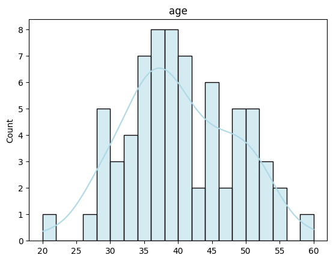

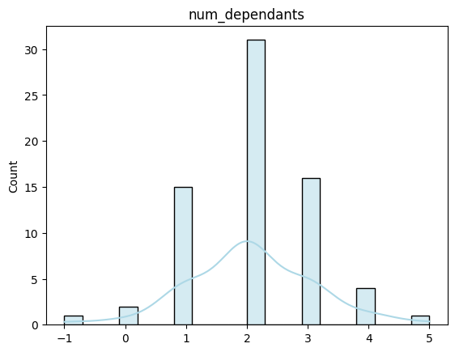

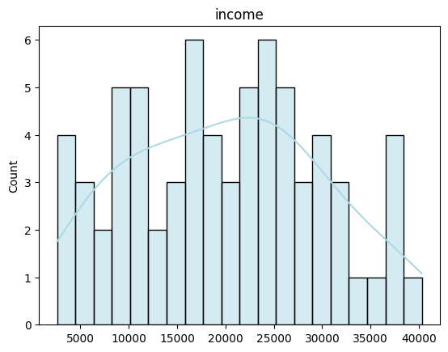

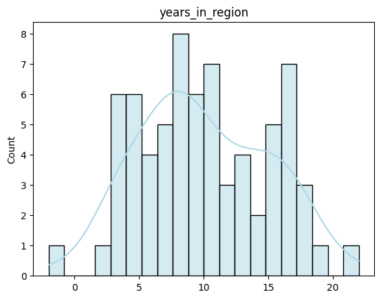

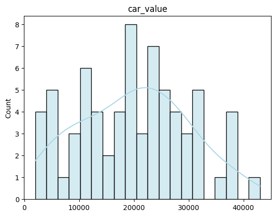

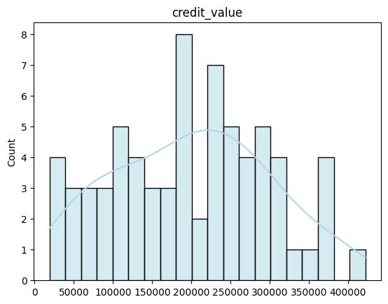

```python
for col_name in df.columns:
    sns.histplot(df[col_name], bins=20, kde=True, color="lightblue", edgecolor="black")
    plt.title(col_name)
    plt.show()
```

Заполнение возможных пропусков средним:

```python
df = df.fill_null(strategy="mean")
```

Проверка на выбросы при помощи IQR метода:

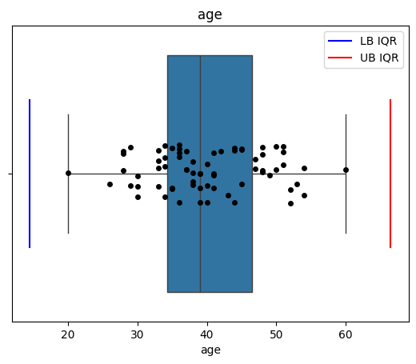

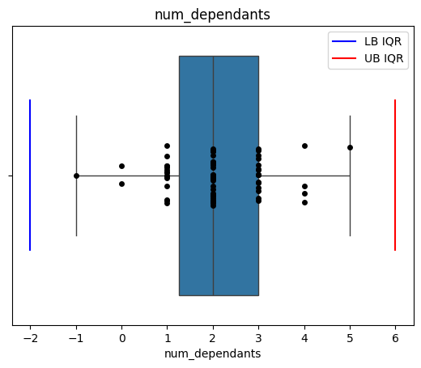

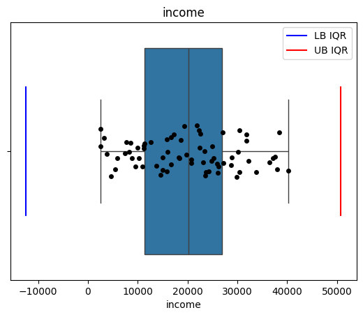

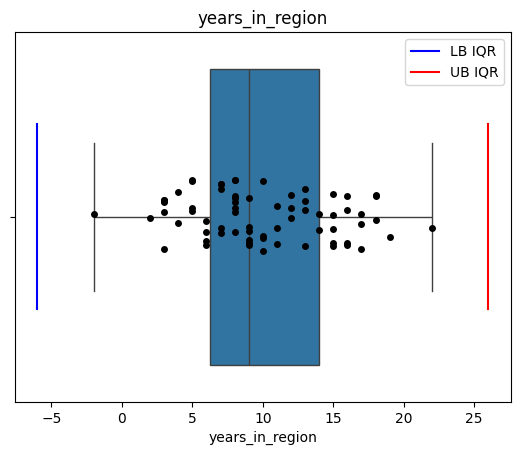

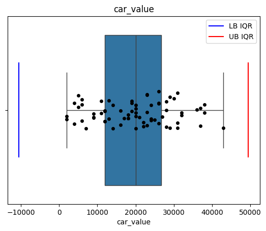

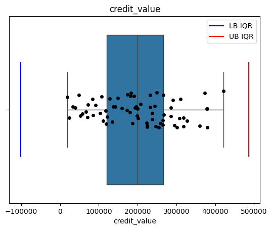

```python
df_orig_size = len(df)

for col_name in df.columns:

    plt.title(col_name)
    sns.boxplot(x=df[col_name])

    Q1 = df[col_name].quantile(0.25)
    Q3 = df[col_name].quantile(0.75)
    IQR = Q3 - Q1

    lower_bound = Q1 - 1.5 * IQR
    upper_bound = Q3 + 1.5 * IQR

    plt.axvline(lower_bound, ymin=0.25, ymax=0.75, color="b", label="LB IQR")
    plt.axvline(upper_bound, ymin=0.25, ymax=0.75, color="r", label="UB IQR")

    sns.stripplot(
        x=df.filter(
            (pl.col(col_name) >= lower_bound) & (pl.col(col_name) <= upper_bound)
        )[col_name],
        color="black",
    )
    sns.stripplot(
        x=df.filter((pl.col(col_name) < lower_bound))[col_name],
        color="blue",
        marker="X",
    )
    sns.stripplot(
        x=df.filter((pl.col(col_name) > upper_bound))[col_name], color="red", marker="X"
    )

    plt.legend()
    plt.show()

    df = df.filter(
        (pl.col(col_name) >= lower_bound) & (pl.col(col_name) <= upper_bound)
    )
```

В данных не обнаружено выбросов. Проведем нормировку и центрорование признаков, так как они имеют разный масштаб:

```python
for col_name in df.columns:
    df = df.with_columns((pl.col(col_name) - df[col_name].mean()).alias(col_name))
    df = df.with_columns(
        (pl.col(col_name) / np.linalg.norm(df[col_name].to_numpy())).alias(col_name)
    )
```

```python
df.describe()
```

shape: (9, 7)

| statistic str | age f64 | num_dependants f64 | income f64 | years_in_region f64 | car_value f64 | credit_value f64 |
| --- | --- | --- | --- | --- | --- | --- |
| "count" | 70.0 | 70.0 | 70.0 | 70.0 | 70.0 | 70.0 |
| "null_count" | 0.0 | 0.0 | 0.0 | 0.0 | 0.0 | 0.0 |
| "mean" | -2.1411e-17 | -3.6479e-17 | -6.7406e-18 | 1.9032e-17 | 8.7232e-18 | -1.5860e-18 |
| "std" | 0.120386 | 0.120386 | 0.120386 | 0.120386 | 0.120386 | 0.120386 |
| "min" | -0.297963 | -0.360366 | -0.209484 | -0.286909 | -0.218439 | -0.217915 |
| "25%" | -0.08924 | -0.125709 | -0.104742 | -0.094951 | -0.09718 | -0.097529 |
| "50%" | -0.014696 | -0.008381 | 0.008428 | -0.022966 | -0.000173 | -0.000017 |
| "75%" | 0.104575 | 0.108948 | 0.085479 | 0.097007 | 0.084708 | 0.079437 |
| "max" | 0.298389 | 0.343605 | 0.244398 | 0.288965 | 0.278723 | 0.267238 |

2. Снижение размерности

```python
from sklearn.decomposition import PCA

pca = PCA(n_components=2)
data_2d = pca.fit_transform(df)
```

```python
pca.explained_variance_ratio_
```

```
array([0.52708336, 0.46351534])
```

```python
sum(pca.explained_variance_ratio_)
```

```
0.9905987063687457
```

Суммарная доля объясненной дисперсии по первым двум компонентам близка 1, что означает, что выводы, сделанные при помощи визуального анализа двумерной карты будут вполне обоснованными.

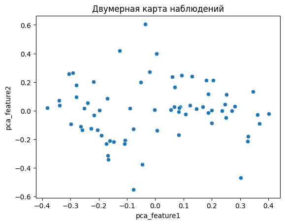

```python
plt.title('Двумерная карта наблюдений')
plt.xlabel('pca_feature1')
plt.ylabel('pca_feature2')
sns.scatterplot(x=data_2d[:, 0], y=data_2d[:, 1])
```

Визуально сложно выделить кластера, предположительно вертикальная линия по середине может разграничить группы заемщиков.

3. Кластеризация

Алгоритм кластеризации на основе MST:

```python
def MST_clustering(n_clusters, sim_matrix):
    G = nx.Graph()
    num_points = sim_matrix.shape[0]

    # Добавляем узлы
    G.add_nodes_from(range(num_points))

    # Добавляем рёбра с весами
    for i in range(num_points):
        for j in range(i + 1, num_points):
            G.add_edge(i, j, weight=sim_matrix[i, j])

    # Построение максимального остовного дерева (MST) алгоритмом Краскала
    mst = nx.maximum_spanning_tree(G)

    # Рисуем MST
    plt.figure(figsize=(20, 30))
    plt.title("Граф MST")
    nx.draw_planar(mst, node_color="skyblue", edge_color="blue", with_labels=True, width=2)
    plt.show()

    # Удаление самого короткого ребра
    for i in range(n_clusters - 1):
        sorted_edges = sorted(mst.edges(data=True), key=lambda x: x[2]["weight"])
        shortest_edge = sorted_edges[0]  # самое короткое ребро
        mst.remove_edge(shortest_edge[0], shortest_edge[1])
        # print(shortest_edge[0], shortest_edge[1])

    # Получаем компоненты связности
    clusters_mst = list(nx.connected_components(mst))

    plt.figure(figsize=(25, 15))

    for i, cluster in enumerate(clusters_mst, start=1):
        subgraph = mst.subgraph(cluster)  # Создаём подграф для кластера

        plt.subplot(1, n_clusters, i)
        nx.draw_planar(
            subgraph,
            with_labels=True,
            node_color="skyblue",
            edge_color="blue",
            node_size=700,
            font_weight="bold",
        )
        plt.title(f"Граф кластера {i}")
        plt.xlabel("X")
        plt.ylabel("Y")

    plt.tight_layout()
    plt.show()

    for i, cluster in enumerate(clusters_mst, start=1):
        print(f"Кластер {i}: {sorted(cluster)}")

    return G, clusters_mst
```

Вычисление матрицы расстояний и переход в матрицу близости:

```python
def get_dist_matrix(matrix, metric="euclidean"):
    dist_vector = pdist(matrix, metric=metric)
    return squareform(dist_vector)
```

```python
d_matrix_euclidean = get_dist_matrix(df, metric="euclidean")
```

```python
def get_similarity_matrix(d_matrix, sigma = np.pi):
    sim_matrix = np.exp(-(d_matrix)**2/(2*(sigma)**2))
    return sim_matrix
```

```python
sim_matrix = get_similarity_matrix(d_matrix_euclidean)
```

Применение алгоритма:

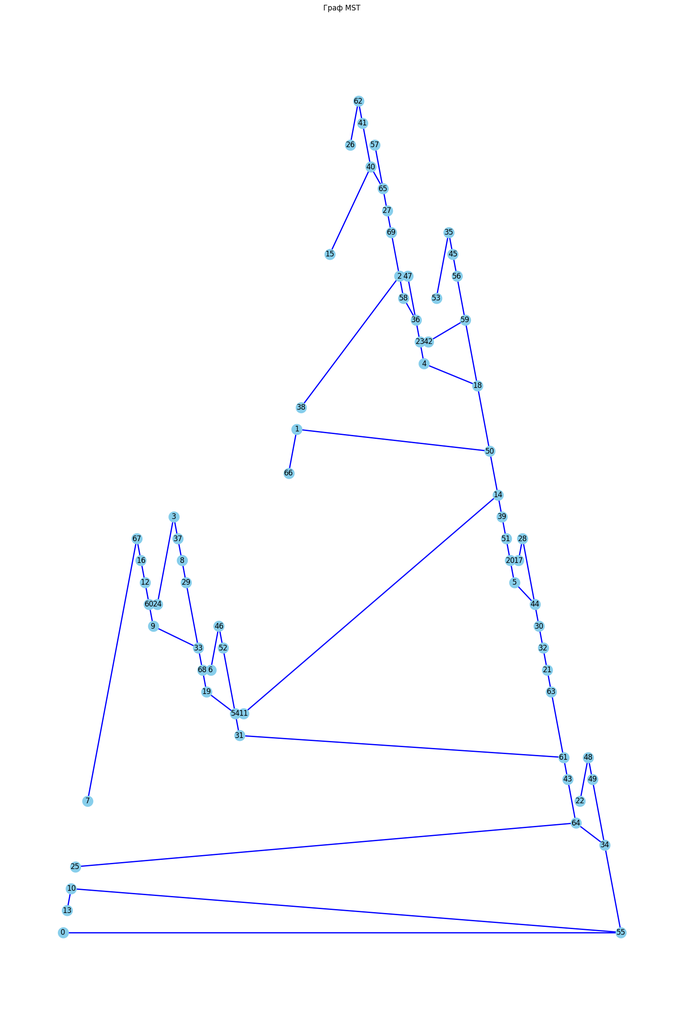

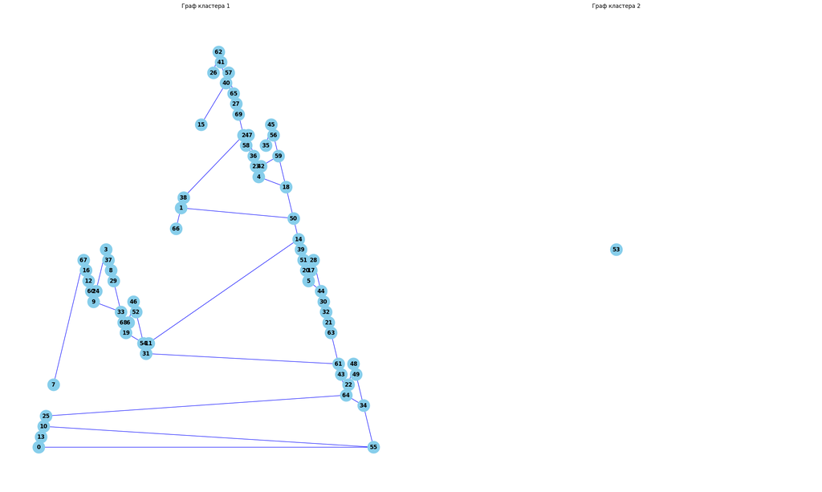

```
Кластер 1: [0, 1, 2, 3, 4, 5, 6, 7, 8, 9, 10, 11, 12, 13, 14, 15, 16, 17, 18, 19, 20, 21, 22, 23, 24, 25, 26, 27, 28, 29, 30, 31, 32, 33, 34, 35, 36, 37, 38, 39, 40, 41, 42, 43, 44, 45, 46, 47, 48, 49, 50, 51, 52, 54, 55, 56, 57, 58, 59, 60, 61, 62, 63, 64, 65, 66, 67, 68, 69]
Кластер 2: [53]
```

```python
G, clusters_mst = MST_clustering(2, sim_matrix)
```

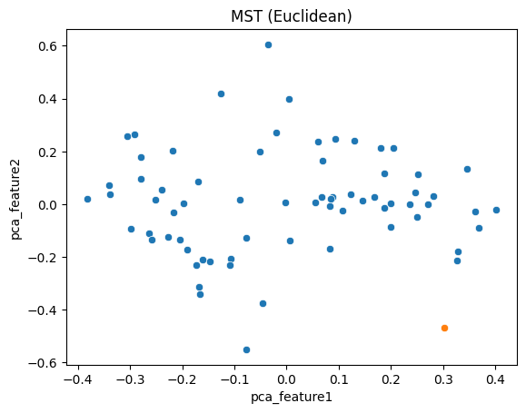

```python
plt.title('MST (Euclidean)')
plt.xlabel('pca_feature1')
plt.ylabel('pca_feature2')
for i in range(len(clusters_mst)):
    sns.scatterplot(x=data_2d[list(clusters_mst[i])][:, 0], y=data_2d[list(clusters_mst[i])][:, 1])
```

Метод MST выделяет 1 вершину в отдельный кластер, карта двумерных признаков может дать нам представление о причине - вполне возможно, что минимальным ребром MST эта вершина была инцидентна, не имею прочих соседей (на карте оранжевая точка - единсвтенный представитель второго кластера).

Оценим разбиение при помощи метрики силуэта:

```python
def get_labels_from_clusters(clusters):
    labels = np.zeros(sum([len(c) for c in clusters]), dtype=int)
    for i, cluster in enumerate(clusters):
        labels[list(cluster)] = i
    return labels
```

```python
silhouette_score(df, get_labels_from_clusters(clusters_mst))
```

```
0.35545198551661106
```

Значение метрики достаточно низко, что говорит о плохом качестве кластеризации в терминах соотношения расстояния между точками и их кластерами и чужими кластерами, что измеряет метрика силуэта.

Сравнение по RAND индексу с кластеризацией по действительным оценкам заемщиков.

```python
def count_pairs_disjoin(left_set: set, right_sets: list):
    left_set_pairs_cnt = len(left_set) * (len(left_set) - 1)

    for rs in right_sets:
        separation = left_set.intersection(rs)
        left_set_pairs_cnt = left_set_pairs_cnt - len(separation) * (
            len(separation) - 1
        )

    return left_set_pairs_cnt


def count_pairs_join(left_set: set, right_sets: list):
    left_set_pairs_cnt = 0

    for rs in right_sets:
        separation = left_set.intersection(rs)
        left_set_pairs_cnt = left_set_pairs_cnt + len(separation) * (
            len(separation) - 1
        )

    return left_set_pairs_cnt


def get_rand_index(part1: list, part2: list):
    left_sets = part1
    right_sets = part2

    left_pair_union = sum([count_pairs_join(x, right_sets) for x in left_sets])
    right_pair_union = sum([count_pairs_join(x, left_sets) for x in right_sets])

    union_cnt = left_pair_union + right_pair_union

    left_pair_diff = sum([count_pairs_disjoin(x, right_sets) for x in left_sets])
    right_pair_diff = sum([count_pairs_disjoin(x, left_sets) for x in right_sets])

    diff_cnt = left_pair_diff + right_pair_diff

    return union_cnt / (union_cnt + diff_cnt)
```

Представление разметки, как кластеризации:

```python
gt_arr = full_df["is_a_good_client"].to_numpy()
```

```python
gt_arr
```

```
array([1, 0, 0, 1, 0, 0, 1, 0, 1, 1, 1, 0, 1, 1, 0, 0, 0, 0, 0, 1, 0, 1,
       1, 0, 1, 1, 0, 0, 0, 1, 0, 1, 0, 1, 1, 0, 0, 1, 0, 0, 0, 0, 0, 1,
       0, 0, 1, 0, 1, 1, 0, 0, 1, 0, 1, 1, 0, 0, 0, 0, 1, 1, 0, 1, 1, 0,
       0, 0, 1, 0])
```

```python
gt_clusters = [set(np.arange(len(gt_arr))[gt_arr == 0].tolist()),set(np.arange(len(gt_arr))[gt_arr == 1].tolist())]
```

```python
get_rand_index(clusters_mst, gt_clusters)
```

```
0.6604886267902275
```

Значение RAND индекса относительно велико, однако проводя параллель с предполагаемой задачей классификации (обучение с учителем, возникающее при наличии разметки данных из посленего столбца), можно было бы сказать, что модель имеет сильный перекос в 1 из классов.

Немалое значение индекса же можно связать с тем, что MST отнеславсе точки в один кластер, что в сравнении с истинной разметкой дает большое перечесение в одном из классов.

Таким образом, MST метод в данном случае плохо разделяет заемщиков по их благонадежности.

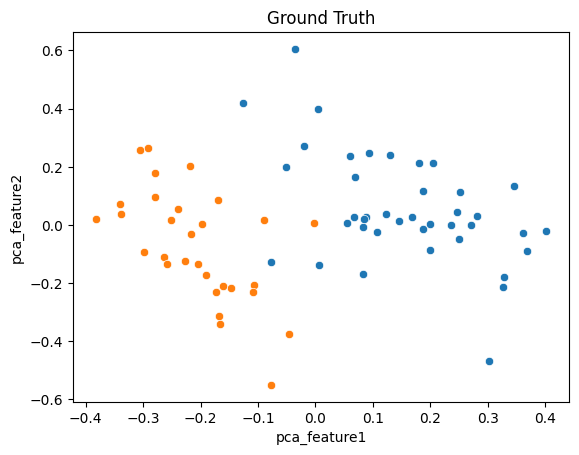

```python
plt.title('Ground Truth')
plt.xlabel('pca_feature1')
plt.ylabel('pca_feature2')
for i in range(len(gt_clusters)):
    sns.scatterplot(x=data_2d[list(gt_clusters[i])][:, 0], y=data_2d[list(gt_clusters[i])][:, 1])
```

Заново обратившись к вдумерной карте признаков и используя разметку как кластеризацию видно, что предположение из 2 пункта о вертикальной черте было близко к правде.